# Fakultät für Physik

## Physikalisches Praktikum P2 für Studierende der Physik

Versuch P2-72, 73, 83 (Stand: März 2024)

[Raum F2-19](https://labs.physik.kit.edu/img/Praktikum/Lageplan_P2.png)

# Gammaspektroskopie

Name: Alhelo Vorname: Fadi E-Mail: uylex@student.kit.edu

\begin{equation*} \begin{split} &\\ &\\ \end{split} \end{equation*}

Name: Ji Vorname: Tony E-Mail: uvsvo@student.kit.edu

\begin{equation*} \begin{split} &\\ &\\ &\\ \end{split} \end{equation*}

Gruppennummer: DO 14

\begin{equation*} \begin{split} &\\ &\\ &\\ \end{split} \end{equation*}

Betreuer: __________________

\begin{equation*} \begin{split} &\\ &\\ &\\ \end{split} \end{equation*}

Versuch durchgeführt am: __________________

**Beanstandungen zu Protokoll Version _____:**

\begin{equation*} \begin{split} &\\ &\\ &\\ &\\ &\\ &\\ &\\ &\\ &\\ &\\ \end{split} %\text{\vspace{10cm}} \end{equation*}

Testiert am: __________________ Testat: __________________

# Durchführung

**Die Anleitung zu diesem Versuch finden Sie [hier](https://gitlab.kit.edu/kit/etp-lehre/p2-praktikum/students/-/blob/main/Gammaspektroskopie/README.md).**

## Aufgabe 1: Messanordnung

**Hinweise zu Aufgabe 1 finden in der Datei Hinweise-Versuchsdurchfuehrung.md.**

- Machen Sie sich mit der Messanordnung vertraut.
- Bearbeiten Sie hierzu die folgenden Aufgaben.

### Aufgabe 1.1: Beschreibung der Messanordnung

- Beschreiben Sie die Messanordnung, die Sie für diesen Versuch vorfinden in eigenen Worten.

**Lösung:**

Zum Messen der Strahlung der radioaktiven Proben wird diese wie in **Abbildung 1.1.1** gezeigt über dem Messgerät festgespannt. Der Messgerät ist der in den Hinweisen beschriebene Szintillator und Detektormaterial. Dieses Aparat ist in der Abbildung innerhalb des silbernen Zylenders zu finden. Die in der Abbildung zu sehende Probe (der Festgespannte blaue Zylinder) ist $_{11}^{22}Na$.

[figure not shown]

**Abbildung 1.1.1:** Aufbau der Messanlage

Das gemessene Signal wird dann druch den MCA (Multichannelanalizer) durchgeleitet und dann auf dem Rechner visuell aufgetragen.

[figure not shown]

**Abbildung 1.1.2:** Aufnahme des MCA

Im laufe des Verscuhes wird das MCA als Oszilloskop eingesezt um den Signal zu untersuchen (genaueres dazu unter Aufgabe 1.2) und im späteren Verlauf dazu verwendet, um einen Histogramm mithilfe der Verschiedenen Signale zu erstellen.

### Aufgabe 1.2: Oszilloskopische Untersuchung des Signal

- Untersuchen Sie das Signal eines beliebigen radioaktiven Präparats.
- Verwenden Sie hierzu den MCA als Oszilloskop.
- Beschreiben Sie Ihre Beobachtungen.

**Lösung:**

Es wird in Abbildung 1.2.1 die Aufnahme der Gruppe Do-02 verwendet, da diese von besserer Qualität ist.

In Abbildung 1.2.1 Ist eine Aufnahme des Signales mithilfe der Osziloskop funktion zu sehen.  
Die unterschiedliche Stärke der Ausschläge zeigt hierfür die unterschiedliche Energien die gemessen wurden.  
Zudem sind die Zeitintervalle zwischen den einzelnen aufgenommenen Signale sehr unregelmäßig. Diese entsprechen die statistische Natur des radioactiven Zerfalls.

[figure not shown]

**Abbildung 1.2.1:** Aufnahme des Signales

### Aufgabe 1.3: Spektrale Untersuchung des Signal

- Untersuchen Sie zur Vorbereitung auf **Aufgabe 2** die Spektren der Präparate $_{\hphantom{0}55}^{137}\mathrm{Cs}$, $_{27}^{60}\mathrm{Co}$ und $_{11}^{22}\mathrm{Na}$.
- Verwenden Sie hierzu den MCA in seiner eigentlichen Eigenschaft als Spektrumanalysator.
- Bestimmen Sie einen einheitlichen dynamischen Bereich, des MCA mit dem Sie alle folgenden Spektren aufzeichnen werden.

**Lösung:**

In der Abbildung 1.3.1 sind die einzelne Messwerte über einem Histogramm aufgetragen. Durch diese Verarbeitung des Signals, typische Verläufe sichtbar.  
In Aufgabe2.2 wird auf diese genauer eingegangen.

Zum bestimmen des Einheitlichen Berieches wurde die Messung mit den Präparate $_{55}^{137}\mathrm{Cs}$, $_{27}^{60}\mathrm{Co}$ und $_{11}^{22}\mathrm{Na}$ durchgeführt. Unter anlegen verschiedener Spannungen ist zu erkennen, dass sich die Aufgenommene Muster stauchen oder strecekn. Dies sieht man bei dem Vergleichen der verschiedenen Abbildungen.Zum festlegen der Spannung wird die Spannung gewählt bei dem eins der Spekten der Präparate and dem rechten Rand des Messbereichs kommt.  
Es wird bei alle Messungen eine Spannung von $683 V$ angelegt.

[figure not shown]

**Abbildung 1.3.1:** Histogramm der $_{55}^{137}Cs$-Probe

[figure not shown]

**Abbildung 1.3.2:** Histogramm der $_{11}^{22}Na$-Probe

[figure not shown]

**Abbildung 1.3.3:** Histogramm der $_{27}^{60}Co$-Probe

## Aufgabe 2: Analyse der Impulshöhenspektren

**Hinweise zu Aufgabe 2 finden in der Datei Hinweise-Versuchsdurchfuehrung.md.**

- Analysieren Sie die Impulshöhenspektren der Präparate $_{\hphantom{0}55}^{137}\mathrm{Cs}$, $_{27}^{60}\mathrm{Co}$ und $_{11}^{22}\mathrm{Na}$.
- Bearbeiten Sie hierzu die folgenden Aufgaben.

### Aufgabe 2.1: Bestimmung des Untergrunds ohne Präparat

- Führen Sie eine Messung ohne Präparat durch, um ein Spektrum des Untergrunds zu erhalten, der jeder weiteren Messung unterliegt.
- Notieren Sie sich die Zeitspanne, in der Sie das Spektrum aufgenommen haben.

#### Vorbereitung

Hintergrundstrahlung ist überall in der Umwelt vorhanden und stammt aus natürlichen Quellen wie kosmischer Strahlung, radioaktiven Isotopen in der Umgebung (im Boden oder auch in dem Menschlichem körper) und andere Quellen.  
Um die Genauigkeit der Messung zu erhöhen, muss man diese gemessene Untergrundstrahlung von den Messwerten der Präparate zunächst abziehen.

#### Durchführung

Um den Untergrunds Spektrum des Versuches zu erhalten wurde die untenstehende Messung durchgeführt. Die Messung entstand under einer Messdauer von $t=6\text{min}$.  
Diese zeit wurde auch bei den anderen Versuchen (mit der Ausnahme der Cobalt Messung) verwendet.

[figure not shown]

**Abbildung 2.1:** Untergrund Spektrum ohne präparat

### Aufgabe 2.2: Bestimmung der Impulshöhenspektren verschiedener Präparate

- Führen Sie eine Messung für jedes der oben angegebenen Präparate durch.
- Notieren Sie sich die Zeitspanne, in der Sie das jeweilge Spektrum aufgenommen haben.
- Charakterisieren Sie die Spektren, indem Sie **alle Strukturen**, die Sie darin vorfinden identifizieren.
- Fügen Sie Darstellungen der Spektren, **wie gemessen**, ins Protokoll ein. Für die anschließende Versuchsauswertung sollten Sie diese Spektren auf den in **Aufgabe 2.1** bestimmten Untergrund korrigieren und die MCA-Kanäle mit Hilfe der in **Aufgabe 2.3** bestimmten Kalibrationkonstanten auf die Energie des Photons $E_{\gamma}$ kalibrieren.

#### Vorbereitung

##### Detektieren von $\gamma$-Quanten

Da ungeladene $\gamma$-Quanten nicht direkt Atome ionisieren können und keine Coulombwechselwirkungen erzeugen, muss deren Nachweis durch vorhergehende Wechselwirkungen mit Materie erfolgen.  
Für den Versuch sind folgende Phänomen:

- **Photoeffekt:**  
  Bei dem Photoeffekt absorbiert ein Elektron einfallende Photonen und wird dadurch aus dem Atom ausgelöst. Damit dieseer Prozess stattfinden kann, muss die Energie des Photons mindestens die Bindungsenergie des jeweiligem Elektron entsprechen.

  Da hier die Impulserhaltung gelten muss, und dass das Photon nach dem Stoß vollständig absorniert wird, muss eine Wechselwirkung mit dem Kern hier stattfinden.  
  Aufgrund dieser Wechselwirkung mit dem Kern findet der Photoeffekt am wahrscheinlichsten bei Elektron in Kernnähe statt.

[figure not shown]

  **Abbildung 2.2.1:** Feynman Diagramm zum Photoeffekt
- **Comptonstreuung:**  
  Bei der Comptonstreuung überträgt das $\gamma$-Quant einen Teil seines Impulses auf ein sehr schwach gebundenes Elektron eines Atoms. Dieses ”quasifreie“ Elektron erhält einen Teil der Energie des Photons und verlässt die Atomhülle. Durch den unelastischen Stoß verliert das Photon an Energie und ändert seine Richtung. Der maximale Energieübertrag liegt bei einem Streuungswinkel des Photons von $180\degree$.

[figure not shown]

[figure not shown]

  **Abbildung 2.2.3:** Feynman Diagramm zur Paarbildung

##### Verläufe der Signale

- **Photopeak:**  
  Ein Photopeak entsteht, wenn ein Gamma-Quant einen Photoeffekt auslöst. Hierbei ist eigentlich ein senkrechter Strich im Spektrum zu erwarten, jedoch erhält man aufgrund der Messungenauigkeit eine Gaußkurve.
- **Comptonkante:**  
  In diesem Breich handelt es sich um die Comptonstreuung eines Gammaquants. Die Energie ist hier vom Rückstreuwinkel abhängig. Auch hier ist eine scharfe Kante zu erwarten. Wie die Abbildungen 1.3.1 bis 1.3.3 aber zeigen, sieht die Kante nicht wie die erwartete Heavysidefunktion aus. Diesen Prozess wird bei Energien von $100keV$ bis $10MeV$ erwartet.  
  Die Maximale Energie ist durch folgende Formel gegeben:

  $$ E_{CK}=\frac{E_\gamma}{1+\frac{m_0c^2}{2E_\gamma}} $$
- **Rückstreupeak:**  
  Der Rückstreupeak entsteht aufgrund der Tatsache, dass das Präparat in alle Richtungen abstrahlt. Abgestrahlte $\gamma$-Quanten, welche mit Materie in der Umgebung wechsekwirken und eine Comptonstreuung erfhren kann dieses $\gamma$-Quant dann vom Szintillator detektiert werden.  
  Der Quant besitzt die Energie $E_\gamma-E_{CK}$ und lässt sich folglich berechnen.

  $$ E_\gamma^\prime = \frac{E_\gamma}{1+\frac{E_\gamma}{m_0c^2}\cdot \left(1-\cos\theta\right)} $$
- **Pile-Up:**  
  Dieser Effekt ist eine folge der begrenzten Zeitauflösung des Szintillators.  
  Kurz aufeinanderfolgende Photonoen können daher als ein Signal interpretiert werden. Deis führt zu dass ein viel stärkeres Signal aufgenommen wird.  
  Die Zeitspanne, welche der Detektor bräuchte um die Signale unterscheiden zu können wird als *Totzeit* bezeichnet.  
  Bei dem verwendeten Detektor ist die Totzeit genügend klein weshalb dieser Effekt vernachlässigt werden kann.

#### Durchfürhung

Es wird wie in Aufgabe 1 das Präparat aufgebaut und Eine Messung durchgeführ. Leider wurde die Messzeit nicht einheitlich gewählt (was später angesprochen wird) und die Messung für das Präparat $_{27}^{69}Co$ wurde über eine dauer von $t=8\text{min}$ aufgenommen im gegensatz zu alle anderen Messungen welche über eine Zeit von $t=6\text{min}$ gemacht wurden.  
Die Messdauer von $t=6\text{min}$ wurde gewählt weil ab diese Messzeit sich das Histogramm der Messdaten keine erhebliche besserung der Qualität gezeigt hat.

Im Versuch sind folgende Diagramme dabei entstanden:

[figure not shown]

**Abbildung 2.2.4:** Histogramm der $_{55}^{137}Cs$-Probe

[figure not shown]

**Abbildung 2.2.5:** Histogramm der $_{11}^{22}Na$-Probe

[figure not shown]

**Abbildung 2.2.6:** Histogramm der $_{27}^{60}Co$-Probe

#### Auswertung

**Wie in den Diagrammen unten zu sehen ist, sind alle Strukturen hier gut zu erkennen.**

```python
import matplotlib.pyplot as plt
import numpy as np
import kafe2
from IPython.display import display, Math

from tools.gamma_tools import fit_peak,fit_compton


background_peak = np.genfromtxt("./Messungen/Keine_probe.hst")
background_channel = np.arange(len(background_peak))
```

##### Strukturen im Natrium Sprektrum

Durch grobes hischauen lassen sich im Spktrum die folgende signifikante Werte in etwa ablesen:

[output not shown]

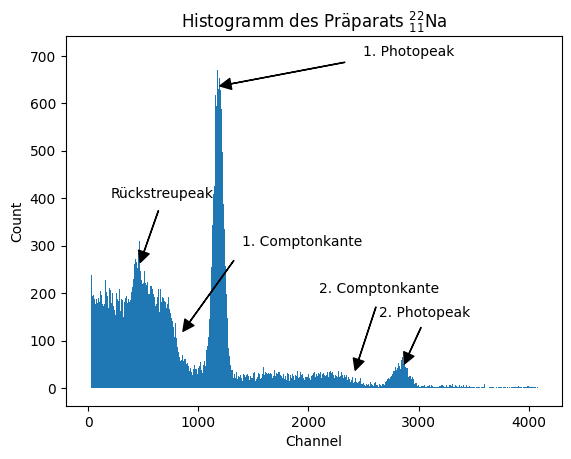

```python
na_peak = np.genfromtxt("./Messungen/Na_probe.hst")
na_channel = np.arange(len(na_peak))

plt.bar(na_channel, na_peak-background_peak, width = 1)
plt.title('Histogramm des Präparats $_{11}^{22}$Na')
plt.xlabel('Channel')
plt.ylabel('Count')

plt.annotate('1. Photopeak', xy=(1050., 630.), xytext=(2500, 700.),
    arrowprops=dict(facecolor='black', shrink=0.1, width=0.2, headwidth=8.,
    headlength=8.))

plt.annotate('2. Photopeak', xy=(2850., 40.), xytext=(2640, 150.),
    arrowprops=dict(facecolor='black', shrink=0.1, width=0.2, headwidth=8.,
    headlength=8.))

plt.annotate('1. Comptonkante', xy=(800., 100.), xytext=(1400, 300.),
    arrowprops=dict(facecolor='black', shrink=0.1, width=0.2, headwidth=8.,
    headlength=8.))

plt.annotate('2. Comptonkante', xy=(2400., 20.), xytext=(2100, 200.),
    arrowprops=dict(facecolor='black', shrink=0.1, width=0.2, headwidth=8.,
    headlength=8.))

plt.annotate('Rückstreupeak', xy=(450., 250.), xytext=(200, 400.),
    arrowprops=dict(facecolor='black', shrink=0.1, width=0.2, headwidth=8.,
    headlength=8.))

plt.show()
```

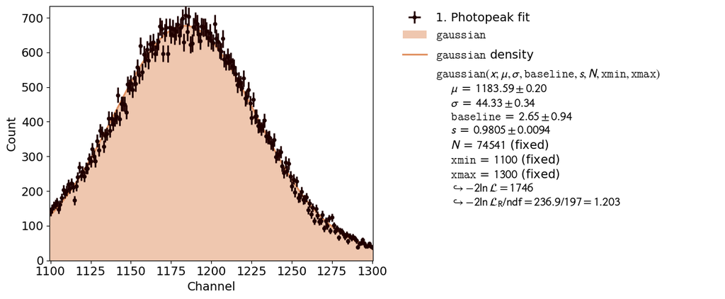

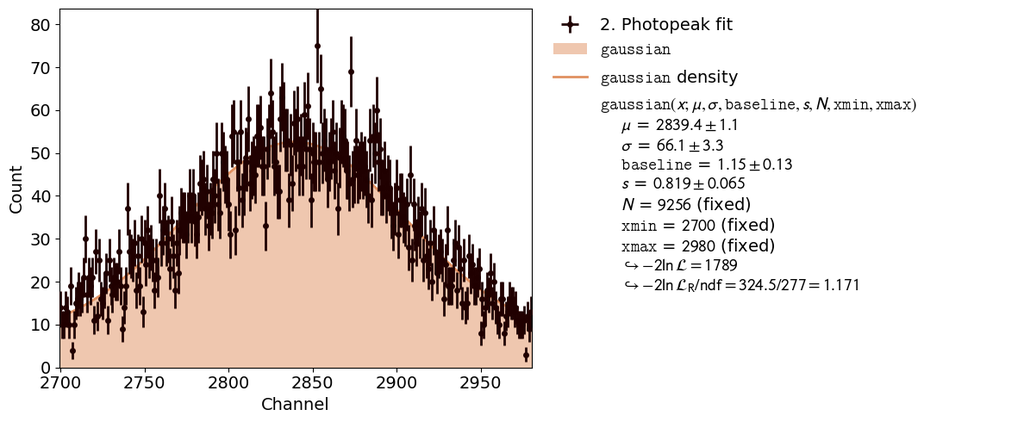

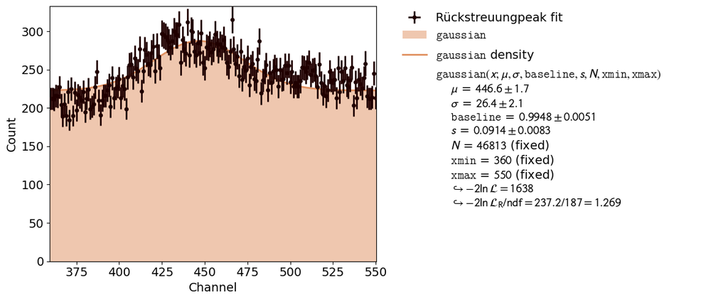

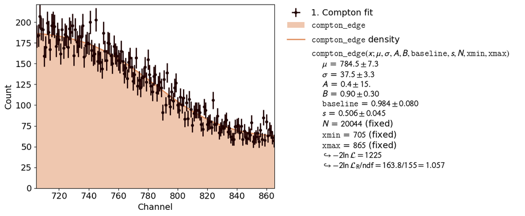

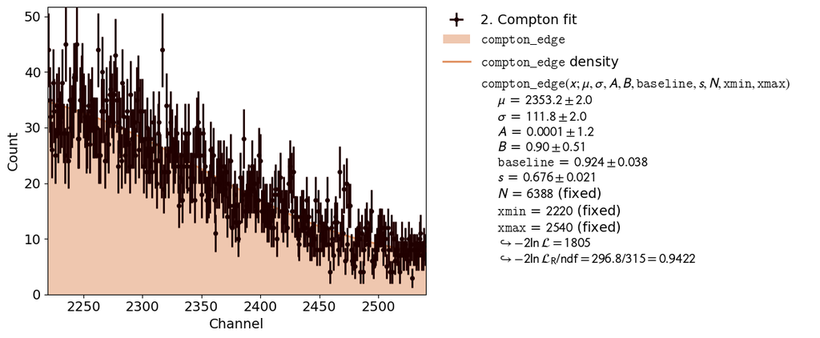

```python
na_peak_fit_1 = fit_peak(na_channel, na_peak, 1100,1300, label = '1. Photopeak fit')
na_peak_fit_2 = fit_peak(na_channel, na_peak, 2700,2980, label = '2. Photopeak fit')

na_ruekpeak_fit = fit_peak(na_channel, na_peak, 360,550, label = 'Rückstreuungpeak fit')

co_compton_fit_1 = fit_compton(na_channel, na_peak, 705, 865, label = '1. Compton fit')
na_compton_fit_2 = fit_compton(na_channel, na_peak, 2220, 2540, label = '2. Compton fit')
```

##### Strukturen im Cobalt Spektrum

Durch grobes hischauen lassen sich im Spktrum die folgende signifikante Werte in etwa ablesen:

[output not shown]

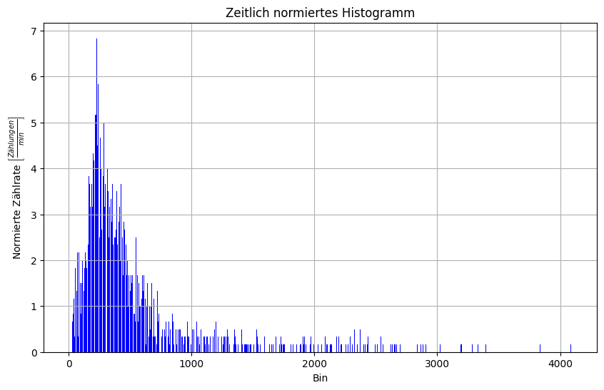

```python
gesamtdauer = 6 # in min

# zeitintervall = gesamtdauer / len(background_peak) # Zeitintervall in Sekunden

# Zeitliche Normierung der Zählraten
normierte_zaehlraten = background_peak / gesamtdauer

# Histogramm plotten
plt.figure(figsize=(10, 6))
plt.bar(range(len(normierte_zaehlraten)), normierte_zaehlraten, width=0.8, color='blue', alpha=1)
plt.xlabel('Bin')
plt.ylabel(rf'Normierte Zählrate $\left[\frac{{Zählungen}}{{min}}\right]$')
plt.title('Zeitlich normiertes Histogramm')
plt.grid(True)
plt.show()
```

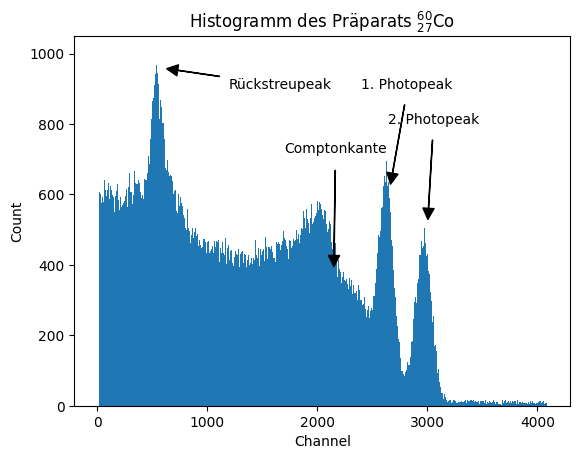

```python
co_peak = np.genfromtxt("./Messungen/Co_probe.hst")
co_channel = np.arange(len(co_peak))

plt.bar(co_channel, co_peak-(normierte_zaehlraten*8), width = 1)
plt.title('Histogramm des Präparats $_{27}^{60}$Co')
plt.xlabel('Channel')
plt.ylabel('Count')

plt.annotate('1. Photopeak', xy=(2650., 600.), xytext=(2400, 900.),
    arrowprops=dict(facecolor='black', shrink=0.1, width=0.2, headwidth=8.,
    headlength=8.))

plt.annotate('2. Photopeak', xy=(3000., 500.), xytext=(2640, 800.),
    arrowprops=dict(facecolor='black', shrink=0.1, width=0.2, headwidth=8.,
    headlength=8.))

plt.annotate('Comptonkante', xy=(2150., 360.), xytext=(1700,720.),
    arrowprops=dict(facecolor='black', shrink=0.1, width=0.2, headwidth=8.,
    headlength=8.))

plt.annotate('Rückstreupeak', xy=(570., 960.), xytext=(1200, 900.),
    arrowprops=dict(facecolor='black', shrink=0.1, width=0.2, headwidth=8.,
    headlength=8.))

plt.show()
```

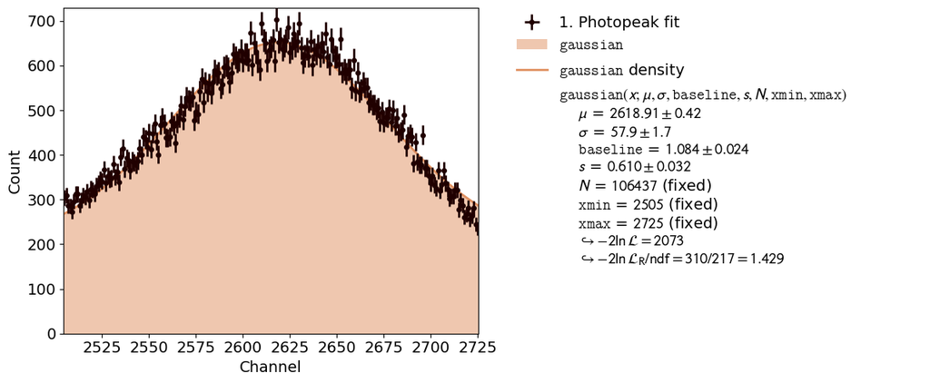

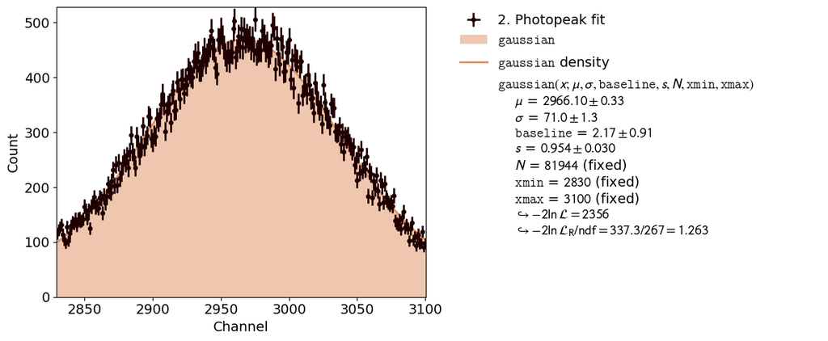

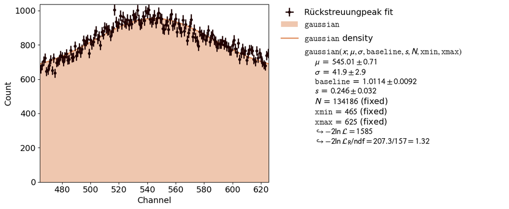

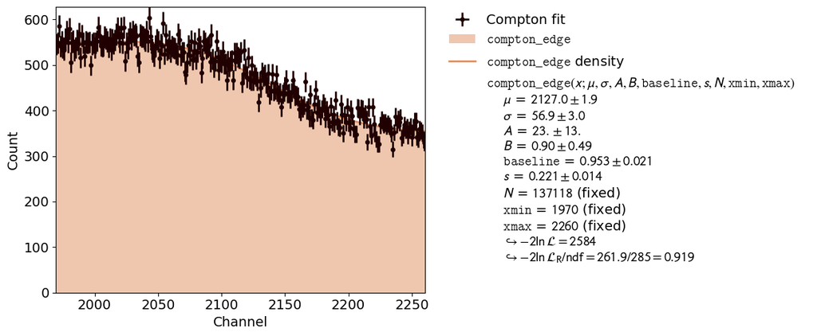

```python
co_peak_fit_1 = fit_peak(co_channel, co_peak, 2505,2725, label = '1. Photopeak fit')
co_peak_fit_2 = fit_peak(co_channel, co_peak, 2830,3100, label = '2. Photopeak fit')

co_ruekpeak_fit = fit_peak(co_channel, co_peak, 465,625, label = 'Rückstreuungpeak fit')

co_compton_fit = fit_compton(co_channel, co_peak, 1970, 2260, label = 'Compton fit')
```

##### Strukturen im Caesium Spektrum

Durch grobes hischauen lassen sich im Spktrum die folgende signifikante Werte in etwa ablesen:

| Art | Entsprechender Channel |
| --- | --- |
| Photopeak | 1500 |
| Rückstreupeak | 500 |
| Comptonkante | 1000 |

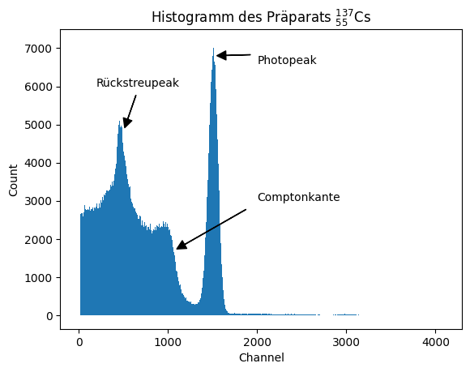

```python
cs_peak = np.genfromtxt("./Messungen/Cs_probe.hst")
cs_channel = np.arange(len(cs_peak))

plt.bar(cs_channel, cs_peak-background_peak, width = 1)
plt.title('Histogramm des Präparats $_{55}^{137}$Cs')
plt.xlabel('Channel')
plt.ylabel('Count')

plt.annotate('Photopeak', xy=(1500., 6800.), xytext=(2000, 6600.),
    arrowprops=dict(facecolor='black', shrink=0.1, width=0.2, headwidth=8.,
    headlength=8.))

plt.annotate('Comptonkante', xy=(1000., 1600.), xytext=(2000,3000.),
    arrowprops=dict(facecolor='black', shrink=0.1, width=0.2, headwidth=8.,
    headlength=8.))

plt.annotate('Rückstreupeak', xy=(500., 4800.), xytext=(200, 6000.),
    arrowprops=dict(facecolor='black', shrink=0.1, width=0.2, headwidth=8.,
    headlength=8.))

plt.show()
```

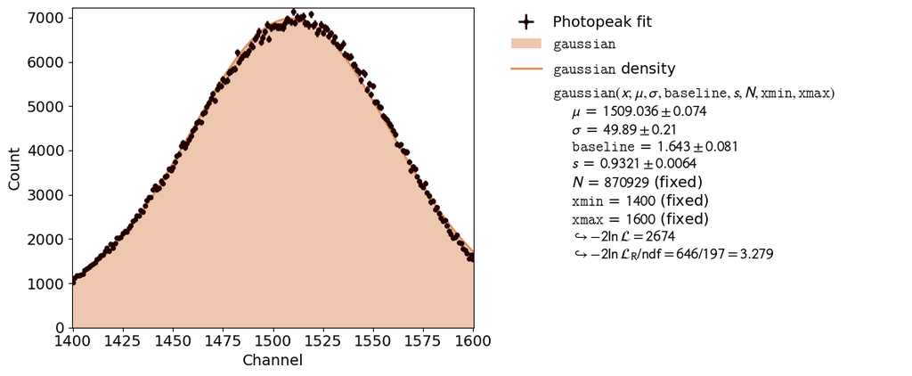

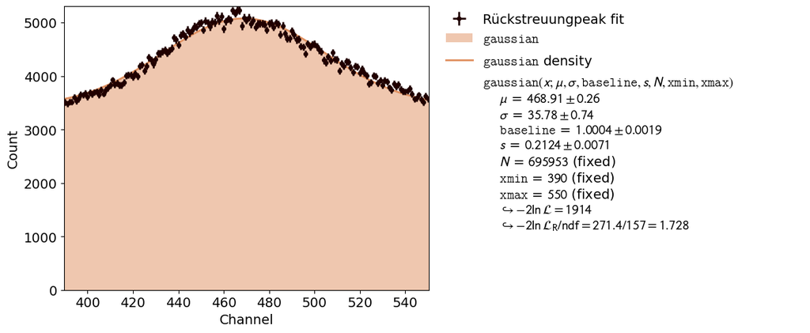

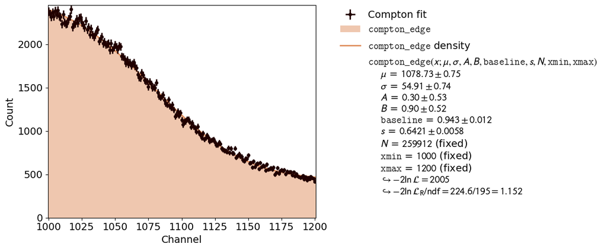

```python
cs_peak_fit = fit_peak(cs_channel, cs_peak, 1400,1600, label = 'Photopeak fit')
cs_ruekpeak_fit = fit_peak(cs_channel, cs_peak, 390,550, label = 'Rückstreuungpeak fit')
cs_compton_fit = fit_compton(cs_channel, cs_peak, 1000, 1200, label = 'Compton fit')
```

Wie man oben aus den Plots entnehman kann, haben die abgeschätzte Werte relativ gut gepasst. Die Abschätzungen haben als gute Grundlage gedient, um die Intervalle für den Fit in erster näherung festzulegen.

#### Energie Plots der Präparate

Mithilfe der in Aufgabe 2.3 ermittelte Parametern zum bestimmung der Energien aus den Kanäle wird die folgende Funktion definiert.

```
code
# Funktion zur Umwandlung von Kanal zu Energie
def channel_to_energie(x,a=0.4605,b=-33):
    return a*x+b
```

Die somit errechnete Werte werden anschließend verwendet, um die Spektren in Abhängigkeit zur Energie abzubilden. Und auch deren signifikante Werte ablesen.

```python
def channel_to_energie(x,a=0.4605,b=-33):
    return a*x+b
```

##### Natrium

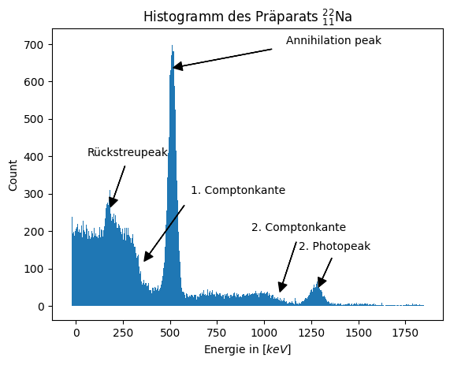

```python
plt.bar(channel_to_energie(na_channel), na_peak-background_peak, width = 1)
plt.title('Histogramm des Präparats $_{11}^{22}$Na')
plt.xlabel('Energie in $[keV]$')
plt.ylabel('Count')

plt.annotate('Annihilation peak', xy=(channel_to_energie(1050), 630.), xytext=(channel_to_energie(2500), 700.),
    arrowprops=dict(facecolor='black', shrink=0.1, width=0.2, headwidth=8.,
    headlength=8.))

plt.annotate('2. Photopeak', xy=(channel_to_energie(2850), 40.), xytext=(channel_to_energie(2640), 150.),
    arrowprops=dict(facecolor='black', shrink=0.1, width=0.2, headwidth=8.,
    headlength=8.))

plt.annotate('1. Comptonkante', xy=(channel_to_energie(800), 100.), xytext=(channel_to_energie(1400), 300.),
    arrowprops=dict(facecolor='black', shrink=0.1, width=0.2, headwidth=8.,
    headlength=8.))

plt.annotate('2. Comptonkante', xy=(channel_to_energie(2400), 20.), xytext=(channel_to_energie(2100), 200.),
    arrowprops=dict(facecolor='black', shrink=0.1, width=0.2, headwidth=8.,
    headlength=8.))

plt.annotate('Rückstreupeak', xy=(channel_to_energie(450), 250.), xytext=(channel_to_energie(200), 400.),
    arrowprops=dict(facecolor='black', shrink=0.1, width=0.2, headwidth=8.,
    headlength=8.))

plt.show()
```

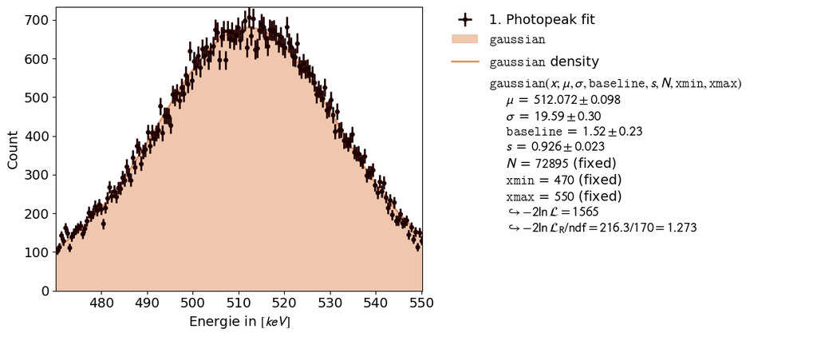

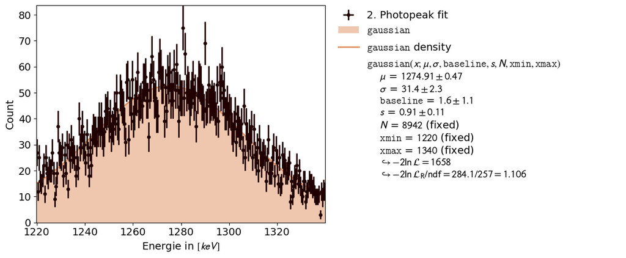

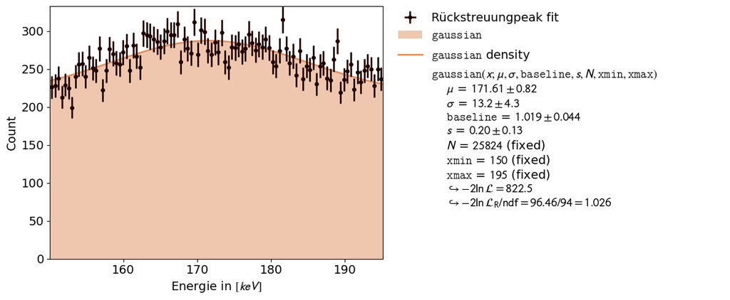

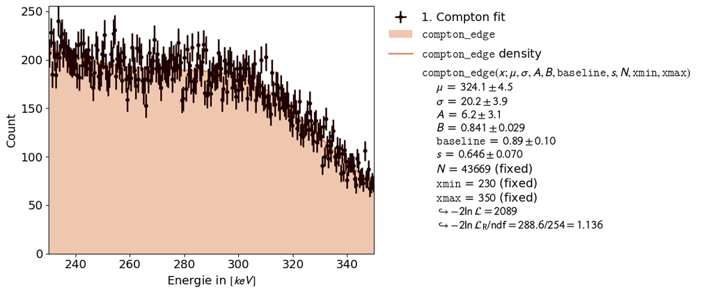

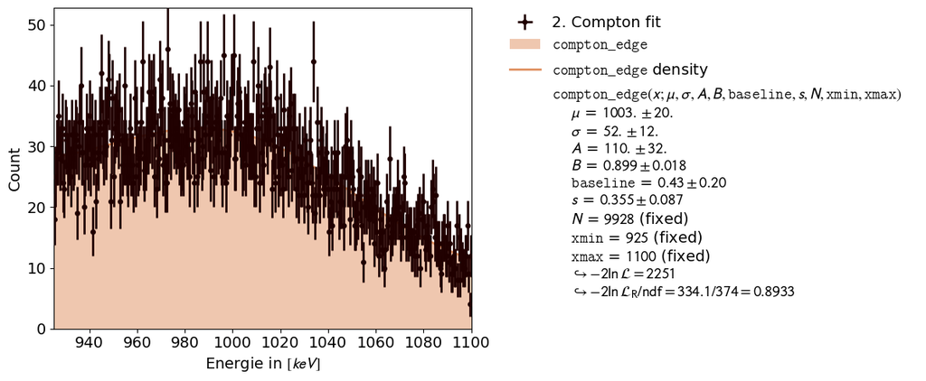

```python
na_peak_fit_1 = fit_peak(channel_to_energie(na_channel), na_peak, 470,550,xlabel=rf'Energie in $[keV]$' ,label = '1. Photopeak fit')
na_peak_fit_2 = fit_peak(channel_to_energie(na_channel), na_peak, 1220,1340,xlabel=rf'Energie in $[keV]$' , label = '2. Photopeak fit')

na_ruekpeak_fit = fit_peak(channel_to_energie(na_channel), na_peak, 150,195,xlabel=rf'Energie in $[keV]$' , label = 'Rückstreuungpeak fit')

co_compton_fit_1 = fit_compton(channel_to_energie(na_channel), na_peak, 230,350,xlabel=rf'Energie in $[keV]$' , label = '1. Compton fit')
na_compton_fit_2 = fit_compton(channel_to_energie(na_channel), na_peak, 925,1100,xlabel=rf'Energie in $[keV]$' , label = '2. Compton fit')
```

$^{22}Na$ ist eine $\beta$-Strahler.  
Das hat zur Folge dass eine viel stärkere $\beta$-Strahlung emitiert. Diese $\beta$-Strahlung wird vom Gehäuße abgefangen und annihiliert. Dadurch kommt es zu eine sehr großen peak bei der Energie von $E\sim 511$, genau die Energie die bei der Annihilation von Positronen entsteht. Durch die Abbildung des Spektrums mit den jeweiligen Energien anstelle der zuvor verwendeten Kanäle lässt sich Feststellen, dass Natrium keine zwei Photopeaks ( wie in der Auswertung der rohen Daten behauptet wurde). Der Aufgezeichnete Peak bei $E\sim 512\,keV$ entstand nicht durch den Photoeffekt sondern durch die Paarbildung. Dies lässt sich hier erkennen genau weil die Energie $E\sim 512\,keV$.  
Diese Energie entspricht auch die Erwartete Energie, welche die Photonen haben würden nachdem ein Elektron-Positron Paar anihiliert.

##### Cobalt

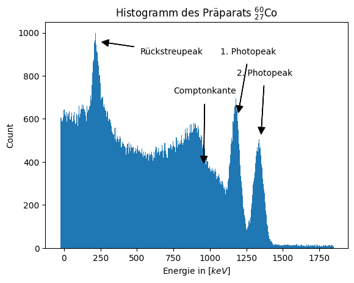

```python
plt.bar(channel_to_energie(co_channel), co_peak-(normierte_zaehlraten*8), width = 1)
plt.title('Histogramm des Präparats $_{27}^{60}$Co')
plt.xlabel('Energie in $[keV]$')
plt.ylabel('Count')

plt.annotate('1. Photopeak', xy=(channel_to_energie(2650), 600.), xytext=(channel_to_energie(2400), 900.),
    arrowprops=dict(facecolor='black', shrink=0.1, width=0.2, headwidth=8.,
    headlength=8.))

plt.annotate('2. Photopeak', xy=(channel_to_energie(3000), 500.), xytext=(channel_to_energie(2640), 800.),
    arrowprops=dict(facecolor='black', shrink=0.1, width=0.2, headwidth=8.,
    headlength=8.))

plt.annotate('Comptonkante', xy=(channel_to_energie(2150), 360.), xytext=(channel_to_energie(1700),720.),
    arrowprops=dict(facecolor='black', shrink=0.1, width=0.2, headwidth=8.,
    headlength=8.))

plt.annotate('Rückstreupeak', xy=(channel_to_energie(570), 960.), xytext=(channel_to_energie(1200), 900.),
    arrowprops=dict(facecolor='black', shrink=0.1, width=0.2, headwidth=8.,
    headlength=8.))


plt.show()
```

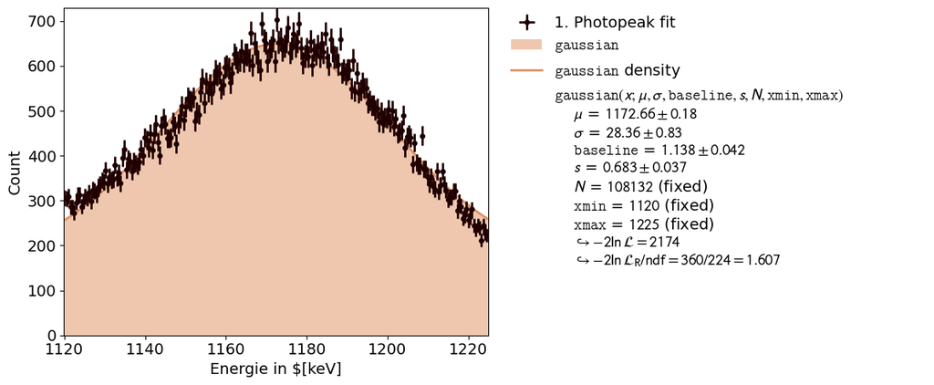

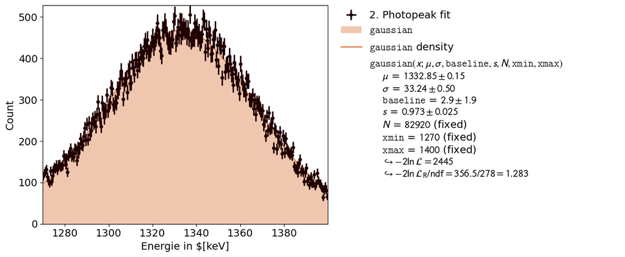

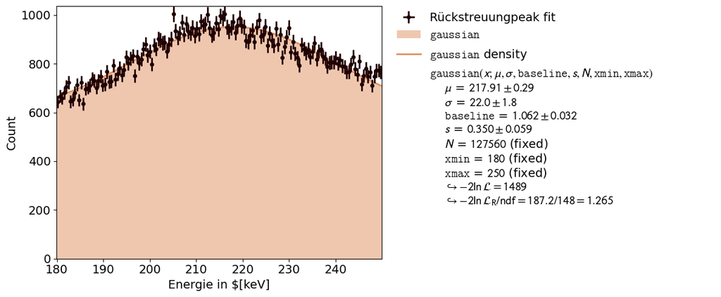

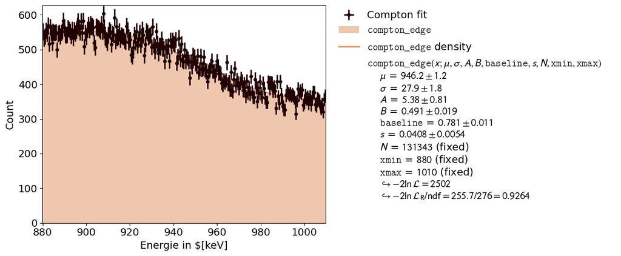

```python
co_peak_fit_1 = fit_peak(channel_to_energie(co_channel), co_peak, 1120,1225,xlabel='Energie in $[keV]', label = '1. Photopeak fit')
co_peak_fit_2 = fit_peak(channel_to_energie(co_channel), co_peak, 1270,1400,xlabel='Energie in $[keV]', label = '2. Photopeak fit')

co_ruekpeak_fit = fit_peak(channel_to_energie(co_channel), co_peak,180,250,xlabel='Energie in $[keV]', label = 'Rückstreuungpeak fit')

co_compton_fit = fit_compton(channel_to_energie(co_channel), co_peak, 880,1010 ,xlabel='Energie in $[keV]', label = 'Compton fit')
```

##### Cäsium

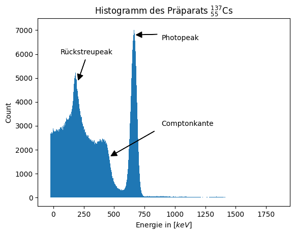

```python
plt.bar(channel_to_energie(cs_channel), cs_peak-background_peak, width = 1)
plt.title('Histogramm des Präparats $_{55}^{137}$Cs')
plt.xlabel('Energie in $[keV]$')
plt.ylabel('Count')

plt.annotate('Photopeak', xy=(channel_to_energie(1500), 6800.), xytext=(channel_to_energie(2000), 6600.),
    arrowprops=dict(facecolor='black', shrink=0.1, width=0.2, headwidth=8.,
    headlength=8.))

plt.annotate('Comptonkante', xy=(channel_to_energie(1000), 1600.), xytext=(channel_to_energie(2000),3000.),
    arrowprops=dict(facecolor='black', shrink=0.1, width=0.2, headwidth=8.,
    headlength=8.))

plt.annotate('Rückstreupeak', xy=(channel_to_energie(500), 4800.), xytext=(channel_to_energie(200), 6000.),
    arrowprops=dict(facecolor='black', shrink=0.1, width=0.2, headwidth=8.,
    headlength=8.))

plt.show()
```

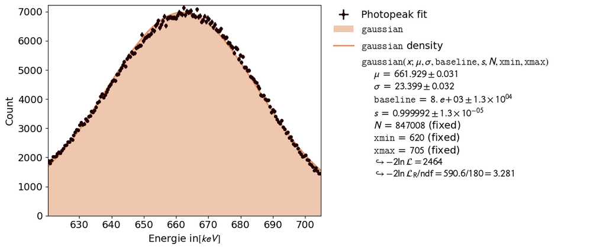

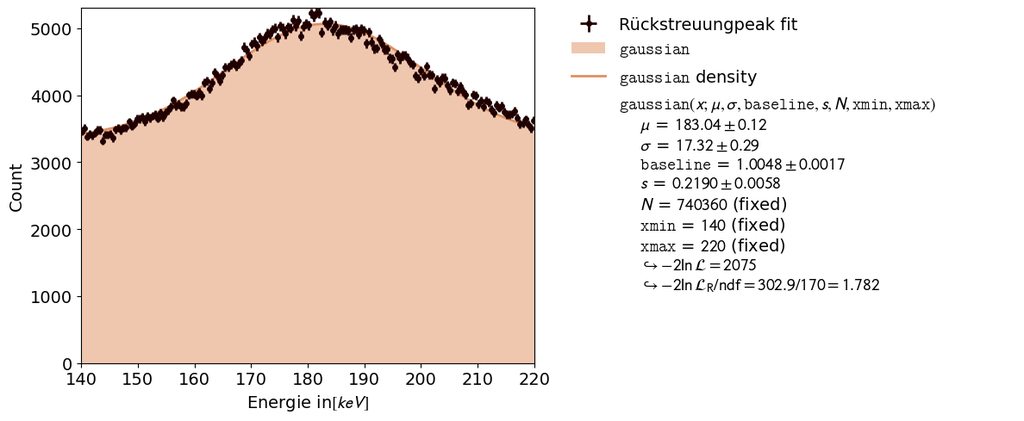

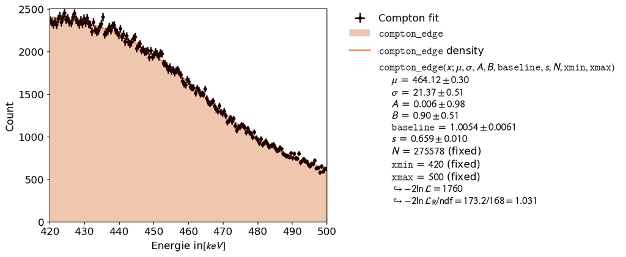

```python
cs_peak_fit = fit_peak(channel_to_energie(cs_channel), cs_peak, 620,705,xlabel='Energie in$[keV]$', label = 'Photopeak fit')
cs_ruekpeak_fit = fit_peak(channel_to_energie(cs_channel), cs_peak, 140,220,xlabel='Energie in$[keV]$', label = 'Rückstreuungpeak fit')
cs_compton_fit = fit_compton(channel_to_energie(cs_channel), cs_peak, 420,500,xlabel='Energie in$[keV]$', label = 'Compton fit')
```

### Aufgabe 2.3: Energie-Kalibration des Detektors

- Kalibieren Sie mit Hilfe der in **Aufgabe 2.2** aufgezeichneten Spektren die Kanäle des MCA auf die Photonenergie $E_{\gamma}$.
- Fügen Sie eine Darstellung der Kalibrationspunkte ins Protokoll ein und passen Sie ein entsprechendes Modell daran an.

**Lösung:**

#### Vorbereitung

An erster Linie sind die kanalnummern der einzelnen Peaks und sofern diese qualitativ gut erkennbar sind auch die Comptonkanten. Diese werden dann im nächsten Schritt ihre bekannten Energien zugeordnet.

[output not shown]

**Abbildung 2.3.1** Messreihe der Kanäle

#### Auswertung

Die in Abbildung 2.3.1 zu findende Werte werden nun an einem linearem Modell gefittet um die regressionsgerade zu bestimmen. Dies wird im unten stehendem Code durchgeführt. Die Form des fits lautet: $$ E = a\cdot\text{Kanal}+b $$ wobei a und b die gesuchten Parameter des Fits sind.

$\displaystyle \text{Für die Energiekalebrirung ergeben sich folgende Parameter: } a=\left(0.4605\pm0.0040\right) \text{und b=}\left(-32.9905\pm10.2439\right)$

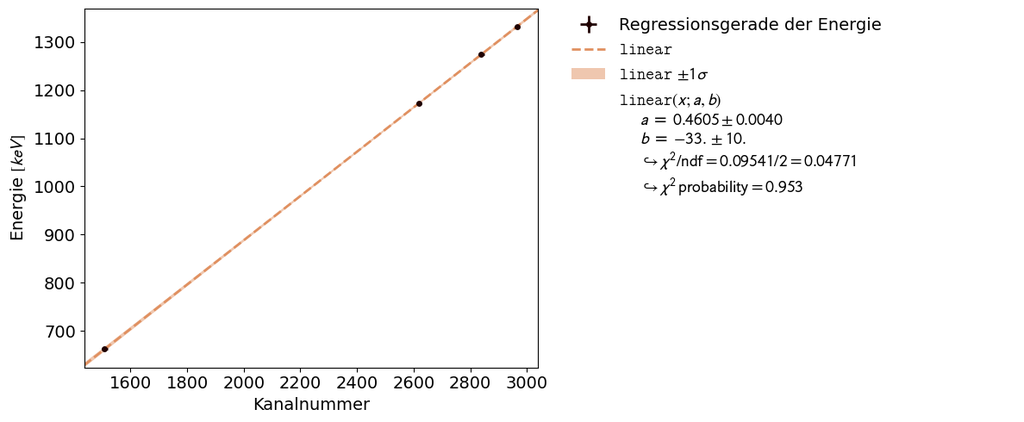

```python
# Daten für Kanalnummern und entsprechende Energien
kanalnummern = np.array([1509, 2619, 2966, 2839])
energien = np.array([661.7, 1173.2, 1332, 1275.5])

# Fit-Funktion definieren (lineare Funktion: y = a * x + b)
def linear(x, a, b):
    return a * x + b

# Dataset erstellen
dataset = kafe2.XYContainer(x_data=kanalnummern,y_data= energien)
dataset.axis_labels=['Kanalnummer', 'Energie $[keV]$']
dataset.label='Regressionsgerade der Energie'

dataset.add_error(axis='x',err_val=10)
dataset.add_error(axis='y',err_val=0.5)

# Fit-Objekt erstellen
fit = kafe2.Fit(dataset, linear)

# Fit durchführen
fit.do_fit()
fit_result=kafe2.Plot([fit])

params =fit.parameter_values
param_errors=fit.parameter_errors

# Ergebnisse ausgeben
display(Math(rf'\text{{Für die Energiekalebrirung ergeben sich folgende Parameter: }} a=\left({params[0]:.04}\pm{param_errors[0]:.4f}\right) \text{{und b=}}\left({params[1]:.04f}\pm{param_errors[1]:.04f}\right)'))

# Fit-Ergebnisse plotten
fit_result.plot()
plt.show()
```

Andhand der hohen $\chi^2$-Wahrscheinlichkeit, können diese Werte mit gutem gewissen übernommen werden.

### Aufgabe 2.4: Relative Energie-Auflösung des Detektors

- Bestimmen Sie mit Hilfe der in **Aufgabe 2.2** aufgezeichneten Spektren die relative Energieauflösung des Detektors als Funktion von $E_{\gamma}$.
- Fügen Sie eine Darstellung der bestimmten Messpunkte ins Protokoll ein und passen Sie ein entsprechendes Modell daran an.
- Schätzen Sie basierend auf dieser Anpassung die erwartete Anzahl ausgeschlagener Elektronen $N_{\mathrm{e}}$ an der Photokathode des im Photodetektor verbauten Photomultipliers ab.

**Lösung:**

#### Vorbereitung

Zur bestimmung der Auflösung sind zuerst zwei Werte benötigt. Der Erwartungswert der Peaks $\mu$ und dessen Halbwertszeit. Diese wird wie folgt aus der Standardabweichung $\sigma$ berechnet $$ \text{FWHM} =2\sqrt{2\ln2}\sigma $$